# Demo

Cheng Ren and revised based on Evan Muzzall’s markdown file

2/5/2020

This is an [.HTML](https://html.com/) file generated using [Rmarkdown (.Rmd)](http://rmarkdown.rstudio.com/). Click these hyperlinks and those throughout this document to learn more.

Be sure to install both R and RStudio for these exercises:  
[Click here to download R(Current Version 3.6.2)](https://www.r-project.org/)  
[Click here to download RStudio](https://www.rstudio.com/products/rstudio/download/)

# learning objectives:

## Navigating RStudio

RStudio is a dynamic [graphical user interface (GUI)](https://www.computerhope.com/jargon/g/gui.htm) that wraps around the R language. You will notice that it is separated into various window panes. RStudio makes it easy to save your code in a [**script.**](https://dzone.com/articles/how-to-write-r-script-explained-with-an-awesome-ex)

To change the color of your background, click **Tools => Global Options => Appearance => Editor theme.** You will probably also want to “soft wrap” your code so that when you type it “wraps” to a new line - you can do this by clicking **Tools => Global Options => Code => check box "Soft wrap R source files.**

To open a new script file, click **File => New File => R Script.** By default this will appear in the upper-left pane. Here you can write code to save variables, import datasets, write comments to yourself, and summarize, visualize, and test data. By default, your output will appear in the lower-left pane called the [**console.**](https://support.rstudio.com/hc/en-us/articles/200404846-Working-in-the-Console)

Variables you define are automatically saved into your [**global environment**](http://adv-r.had.co.nz/Environments.html) - this is physical space tasked with storing the variables you define. This is located in the upper-right pane.

The lower-right pane contains miscellaneous output. Here you will find your file structure, help pages, plots, and a package installation interface.

## Saving variables

To [save a variable](https://www.datacamp.com/courses/free-introduction-to-r) in RStudio, you need three things:  
1) unique name - if your variable name is the same as a previously defined one, it will overwrite it!  
2) the assignment operator <-  
3) a definition/statements to be evaluated - the code you want to run

The syntax looks like this: `unique_name <- definition`, and you read this like “the object unique_name is defined as ‘definition’”.

Run a line of code by pressing **command + return (Mac)** or **Ctrl + return (Windows).** Try it!

```r
my_name <- "Type your name here!" # this is character/text/string data

X <- 5 # R defaults to numeric type, even for whole numbers!
```

## Data types and type coercion

R can store many different [data types](https://swcarpentry.github.io/r-novice-inflammation/13-supp-data-structures/).  
The most common ones are:  
1) **numeric:** decimals and fractions  
2) **integer:** positive and negative whole numbers, including zero  
3) **character:** aka text or string data  
4) **logical:** `TRUE` or `FALSE`  
5) **factor:** categorical groupings of integer or character data

You can investigate data types using the `class()` function.

```r
class(my_name)
```

```
## [1] "character"
```

```r
class(X)
```

```
## [1] "numeric"
```

#### Data type coercion

```r
X_char <- as.character(X)
class(X_char)
```

```
## [1] "character"
```

## Vectors

Vectors are central to R and are defined as organized groupings of the same type of data. This means that their position matters!

So far, we have only been saving one piece of data into our variables. We can use the `c()` funciton to save more than one piece of data, as long as it is all of the same type! Let’s try it:

```r
fruit <- c("Apple", "Apple", "Apple", "Apple",
           "Orange", "Orange", "Orange",
           "Strawberry", "Strawberry", "Strawberry")
fruit
```

```
##  [1] "Apple"      "Apple"      "Apple"      "Apple"      "Orange"
##  [6] "Orange"     "Orange"     "Strawberry" "Strawberry" "Strawberry"
```

```r
class(fruit)
```

```
## [1] "character"
```

Note that we never refer to a vector merely as a vector! We always refer to it by its type: character vector, integer vector, logical vector, and so on.

See these [examples for generating sequences of numbers](http://uc-r.github.io/generating_sequence_numbers/).

## Factors

Factors are categorical groupings of data that can be used to make comparisons between other data.

```r
price <- c(0.79, 0.79, 0.79, 0.79, # price of apples
           0.99, 0.99, 0.99, # oranges
           0.59, 0.59, 0.59) # strawberries
price
```

```
##  [1] 0.79 0.79 0.79 0.79 0.99 0.99 0.99 0.59 0.59 0.59
```

```r
class(price)
```

```
## [1] "numeric"
```

Unfortunately, it is difficult to make comparisons of the prices if we keep the “fruit” vector as character type. However, if we coerce it to factor type, R knows that it should group the like fruits by name.

Similar to type coercion above, we can convert “fruit” from character to factor type using the `as.factor()` function:

```r
fruit_fac <- as.factor(fruit)
fruit_fac
```

```
##  [1] Apple      Apple      Apple      Apple      Orange     Orange
##  [7] Orange     Strawberry Strawberry Strawberry
## Levels: Apple Orange Strawberry
```

```r
class(fruit_fac)
```

```
## [1] "factor"
```

What changed? We can then view the factor levels via the `levels()` function:

```r
levels(fruit_fac)
```

```
## [1] "Apple"      "Orange"     "Strawberry"
```

Get more [help with factors](https://www.stat.berkeley.edu/classes/s133/factors.html) by clicking the link!

## Data frames

A major strength of R is that it can store data in a “data frame”. This allows you to combine vectors of equal length into a dataset that can be operated upon. The best way to think of this is to think of a basic spreadsheet!

```r
fruit_prices <- data.frame(fruit, price)
fruit_prices
```

```
##         fruit price
## 1       Apple  0.79
## 2       Apple  0.79
## 3       Apple  0.79
## 4       Apple  0.79
## 5      Orange  0.99
## 6      Orange  0.99
## 7      Orange  0.99
## 8  Strawberry  0.59
## 9  Strawberry  0.59
## 10 Strawberry  0.59
```

```r
class(fruit_prices)
```

```
## [1] "data.frame"
```

## Changing column names in a data frame

So far, we have only manipulated the right side of our equation! However, we can change the column names of “fruit_prices” by manipulating the left side, and then defining a character vector of length equal to our number of columns. What changed?

```r
colnames(fruit_prices)
```

```
## [1] "fruit" "price"
```

```r
colnames(fruit_prices) <- c("FRUIT", "PRICE")
head(fruit_prices)
```

```
##    FRUIT PRICE
## 1  Apple  0.79
## 2  Apple  0.79
## 3  Apple  0.79
## 4  Apple  0.79
## 5 Orange  0.99
## 6 Orange  0.99
```

## Load the GSS data subset from file with `read.csv()`

Remember to set your working directory first by clicking **Session => Set Working Directory => Choose Directory** and choose the “csv file” folder.

```r
#To check Whether you are in the Working directory
setwd('/Users/cheng/Downloads')
getwd()
```

```
## [1] "C:/Users/cheng/Downloads"
```

```r
#if you have readly in the working directory, you can just read the file
gss <- read.csv("gss_sub.csv", header = T)
?read.csv()
```

```
## starting httpd help server ... done
```

```r
# Or, you can just type the absolute file path into `read.csv()`
gss <- read.csv("/Users/cheng/Downloads/gss_sub.csv", header = T)
#Please be aware it is "/" not "\", if you copy from the file, the address is "\" like"\OneDrive\Desktop"
```

Inspect the data frame

```r
str(gss)
```

```
## 'data.frame':    62466 obs. of  39 variables:
##  $ YEAR    : int  1972 1972 1972 1972 1972 1972 1972 1972 1972 1972 ...
##  $ AGE     : Factor w/ 72 levels "18","19","20",..: 6 53 31 10 44 9 11 10 4 13 ...
##  $ SEX     : Factor w/ 2 levels "FEMALE","MALE": 1 2 1 1 1 2 2 2 1 1 ...
##  $ RACE    : Factor w/ 3 levels "BLACK","OTHER",..: 3 3 3 3 3 3 3 3 1 1 ...
##  $ ETHNIC  : Factor w/ 42 levels "AFRICA","AMERICAN INDIAN",..: NA 18 19 4 40 10 18 NA NA NA ...
##  $ HEALTH  : Factor w/ 4 levels "EXCELLENT","FAIR",..: 3 2 1 3 3 3 1 3 1 2 ...
##  $ EDUC    : int  16 10 12 17 12 14 13 16 12 12 ...
##  $ DEGREE  : Factor w/ 5 levels "BACHELOR","GRADUATE",..: 1 5 3 1 3 3 3 1 3 3 ...
##  $ PAEDUC  : int  10 8 8 16 8 18 16 16 12 10 ...
##  $ MAEDUC  : int  NA 8 8 12 8 19 12 14 12 7 ...
##  $ WRKSTAT : Factor w/ 8 levels "KEEPING HOUSE",..: 7 3 8 7 1 7 7 7 8 7 ...
##  $ DWELLING: Factor w/ 10 levels "2 UNITS-ONE ABOVE",..: NA NA NA NA NA NA NA NA NA NA ...
##  $ MARITAL : Factor w/ 5 levels "DIVORCED","MARRIED",..: 3 2 2 2 2 3 1 3 3 2 ...
##  $ CHILDS  : int  0 5 4 0 2 0 2 0 2 4 ...
```

[output cut: 25 more lines]

```r
dim(gss)
```

```
## [1] 62466    39
```

```r
head(gss)
```

```
##   YEAR AGE    SEX  RACE          ETHNIC    HEALTH EDUC         DEGREE
## 1 1972  23 FEMALE WHITE            <NA>      GOOD   16       BACHELOR
## 2 1972  70   MALE WHITE         IRELAND      FAIR   10 LT HIGH SCHOOL
## 3 1972  48 FEMALE WHITE           ITALY EXCELLENT   12    HIGH SCHOOL
## 4 1972  27 FEMALE WHITE          ARABIC      GOOD   17       BACHELOR
## 5 1972  61 FEMALE WHITE     SWITZERLAND      GOOD   12    HIGH SCHOOL
## 6 1972  26   MALE WHITE ENGLAND & WALES      GOOD   14    HIGH SCHOOL
##   PAEDUC MAEDUC          WRKSTAT DWELLING       MARITAL CHILDS
## 1     10     NA WORKING FULLTIME     <NA> NEVER MARRIED      0
## 2      8      8          RETIRED     <NA>       MARRIED      5
## 3      8      8 WORKING PARTTIME     <NA>       MARRIED      4
## 4     16     12 WORKING FULLTIME     <NA>       MARRIED      0
## 5      8      8    KEEPING HOUSE     <NA>       MARRIED      2
## 6     18     19 WORKING FULLTIME     <NA> NEVER MARRIED      0
##            FAMILY16 BORN LOCKEDUP CONVICTD          PARTYID      RELIG
```

[output cut: 27 more lines]

## Identifying missing data (`NA`)

Missing data are especially problematic in all data science endeavors as identifying missing data is a fundamental step in data preparation. In R, you can identify missing data with the `is.na()` function. Let’s just look at the “HEALTH” column. R recognizes missing data only as `NA`.

`TRUE` means data are missing; `FALSE` means data are present.

```r
is.na(gss$HEALTH)
```

If we want to see sum how many cells have missing data within a vector, we can wrap this in the `sum()` or `table()` function:

```r
sum(is.na(gss$HEALTH)) # the HEALTH column has 16,445 cells with missing data
```

```
## [1] 16445
```

```r
table(is.na(gss$HEALTH))# what is the difference?
```

```
##
## FALSE  TRUE
## 46021 16445
```

If we want see the missing situation of each column

```r
colSums(is.na(gss))
```

```
##     YEAR      AGE      SEX     RACE   ETHNIC   HEALTH     EDUC   DEGREE
##        0      221        0        0    13310    16445      174      173
##   PAEDUC   MAEDUC  WRKSTAT DWELLING  MARITAL   CHILDS FAMILY16     BORN
##    18316    10685       19    12902       25      197     1546     9262
## LOCKEDUP CONVICTD  PARTYID    RELIG    HAPPY     SIBS   HOMPOP   CONINC
##    60718    60718      385      269     4756     1691        6     6324
##  CONRINC   EARNRS EMPYEARS TOTALNUM HRSRELAX  TVHOURS RADIOHRS  EMAILHR
##    25942      558    61563    61897    56620    25059    57962    53371
##    WWWHR NUMFREND   WEALTH POLVIEWS    DRAFT CHLDIDEL  WTSSALL
##    51347    61626    60311     9385    56339    23858        0
```

```r
round(colSums(is.na(gss))/nrow(gss)*100,2)
```

```
##     YEAR      AGE      SEX     RACE   ETHNIC   HEALTH     EDUC   DEGREE
##     0.00     0.35     0.00     0.00    21.31    26.33     0.28     0.28
##   PAEDUC   MAEDUC  WRKSTAT DWELLING  MARITAL   CHILDS FAMILY16     BORN
##    29.32    17.11     0.03    20.65     0.04     0.32     2.47    14.83
## LOCKEDUP CONVICTD  PARTYID    RELIG    HAPPY     SIBS   HOMPOP   CONINC
##    97.20    97.20     0.62     0.43     7.61     2.71     0.01    10.12
##  CONRINC   EARNRS EMPYEARS TOTALNUM HRSRELAX  TVHOURS RADIOHRS  EMAILHR
##    41.53     0.89    98.55    99.09    90.64    40.12    92.79    85.44
##    WWWHR NUMFREND   WEALTH POLVIEWS    DRAFT CHLDIDEL  WTSSALL
##    82.20    98.66    96.55    15.02    90.19    38.19     0.00
```

## Summarizing your data

Summarizing data are a fundamental step in the analytical process, often even before visualization. You want to quickly produce some descriptive statistics since they can inform what you should consider choosing for your visualizations.

The `summary()` and `table()` functions are great places to start:

```r
table(gss$HEALTH) # this will compute frequencies for factor variables
```

```
##
## EXCELLENT      FAIR      GOOD      POOR
##     13827      8768     20788      2638
```

```r
gss$HEALTH<-factor(gss$HEALTH, levels=c('EXCELLENT' ,'GOOD' ,'FAIR','POOR'))# change the levels(orders) of the variable
table(gss$HEALTH) # compare the difference between the original one
```

```
##
## EXCELLENT      GOOD      FAIR      POOR
##     13827     20788      8768      2638
```

```r
summary(gss$CONINC) # this will produce six number summaries for numeric variables
```

```
##    Min. 1st Qu.  Median    Mean 3rd Qu.    Max.    NA's
##     363   18241   35602   44839   59569  180386    6324
```

```r
aggregate(gss$CONINC, by = list(gss$HEALTH),summary)
```

```
##     Group.1    x.Min. x.1st Qu.  x.Median    x.Mean x.3rd Qu.    x.Max.
## 1 EXCELLENT    363.00  25926.00  44643.00  53937.72  72223.00 180386.00
## 2      GOOD    363.00  20062.00  37461.00  45620.58  59895.00 180386.00
## 3      FAIR    363.00  12071.00  24258.00  32934.38  43612.00 180386.00
## 4      POOR    363.00   7693.00  14761.00  23105.93  29574.00 180386.00
##      x.NA's
## 1   1193.00
## 2   1999.00
## 3   1021.00
## 4    365.00
```

```r
aggregate(gss$CONINC, by = list(gss$HEALTH),mean)
```

```
##     Group.1  x
## 1 EXCELLENT NA
## 2      GOOD NA
## 3      FAIR NA
## 4      POOR NA
```

```r
#Please think for a while why it returns NAs
aggregate(gss$CONINC, by = list(gss$HEALTH),mean,na.rm=TRUE)
```

```
##     Group.1        x
## 1 EXCELLENT 53937.72
## 2      GOOD 45620.58
## 3      FAIR 32934.38
## 4      POOR 23105.93
```

Cross Table [supoprt file](http://rstudio-pubs-static.s3.amazonaws.com/6975_c4943349b6174f448104a5513fed59a9.html)

```r
gss$DEGREE<-factor(gss$DEGREE, levels=c("GRADUATE","BACHELOR","JUNIOR COLLEGE","HIGH SCHOOL","LT HIGH SCHOOL"))#change the levels of degree
m<-table(gss$DEGREE,gss$FAMILY16)
m
```

```
##
##                  FATHER FATHER & STPMOTHER FEMALE RELATIVE
##   GRADUATE           54                 62              25
##   BACHELOR          117                140              52
##   JUNIOR COLLEGE     69                 72              27
##   HIGH SCHOOL       736                603             479
##   LT HIGH SCHOOL    479                284             349
##
##                  M AND F RELATIVES MALE RELATIVE MOTHER MOTHER & FATHER
##   GRADUATE                      50             5    357            3618
##   BACHELOR                      90            12    883            7046
##   JUNIOR COLLEGE                67             8    466            2375
##   HIGH SCHOOL                  696            89   4196           22020
##   LT HIGH SCHOOL               473            88   1932            8155
##
##                  MOTHER & STPFATHER OTHER
##   GRADUATE                      108    58
##   BACHELOR                      325   105
##   JUNIOR COLLEGE                194    86
##   HIGH SCHOOL                  1722   681
##   LT HIGH SCHOOL                698   608
```

```r
round(prop.table(m,1),4)*100
```

```
##
##                  FATHER FATHER & STPMOTHER FEMALE RELATIVE
##   GRADUATE         1.25               1.43            0.58
##   BACHELOR         1.33               1.60            0.59
##   JUNIOR COLLEGE   2.05               2.14            0.80
##   HIGH SCHOOL      2.36               1.93            1.53
##   LT HIGH SCHOOL   3.67               2.17            2.67
##
##                  M AND F RELATIVES MALE RELATIVE MOTHER MOTHER & FATHER
##   GRADUATE                    1.15          0.12   8.23           83.42
##   BACHELOR                    1.03          0.14  10.07           80.34
##   JUNIOR COLLEGE              1.99          0.24  13.85           70.60
##   HIGH SCHOOL                 2.23          0.29  13.44           70.53
##   LT HIGH SCHOOL              3.62          0.67  14.79           62.41
##
##                  MOTHER & STPFATHER OTHER
##   GRADUATE                     2.49  1.34
##   BACHELOR                     3.71  1.20
##   JUNIOR COLLEGE               5.77  2.56
##   HIGH SCHOOL                  5.52  2.18
##   LT HIGH SCHOOL               5.34  4.65
```

```r
round(prop.table(m,2),4)*100
```

```
##
##                  FATHER FATHER & STPMOTHER FEMALE RELATIVE
##   GRADUATE         3.71               5.34            2.68
##   BACHELOR         8.04              12.06            5.58
##   JUNIOR COLLEGE   4.74               6.20            2.90
##   HIGH SCHOOL     50.58              51.94           51.39
##   LT HIGH SCHOOL  32.92              24.46           37.45
##
##                  M AND F RELATIVES MALE RELATIVE MOTHER MOTHER & FATHER
##   GRADUATE                    3.63          2.48   4.56            8.37
##   BACHELOR                    6.54          5.94  11.27           16.30
##   JUNIOR COLLEGE              4.87          3.96   5.95            5.50
##   HIGH SCHOOL                50.58         44.06  53.56           50.96
##   LT HIGH SCHOOL             34.38         43.56  24.66           18.87
##
##                  MOTHER & STPFATHER OTHER
##   GRADUATE                     3.54  3.77
##   BACHELOR                    10.67  6.83
##   JUNIOR COLLEGE               6.37  5.59
##   HIGH SCHOOL                 56.51 44.28
##   LT HIGH SCHOOL              22.91 39.53
```

Correcltion is a statistical relationship,it commonly refers to the degree to which a pair of variables are linearly related. The range of correcltion is [-1,1] and negative means negative relationship and vice versa.

```r
cor.test(gss$EDUC,gss$PAEDUC,use = "complete.obs")
```

```
##
##  Pearson's product-moment correlation
##
## data:  gss$EDUC and gss$PAEDUC
## t = 117.79, df = 44087, p-value < 2.2e-16
## alternative hypothesis: true correlation is not equal to 0
## 95 percent confidence interval:
##  0.4821242 0.4963245
## sample estimates:
##       cor
## 0.4892568
```

Alternative way  
glm is used to fit generalized linear models, specified by giving a symbolic description of the linear predictor and a description of the error distribution.

```r
model<-glm(EDUC~PAEDUC,gss,family ="gaussian" )
summary(model)
```

```
##
## Call:
## glm(formula = EDUC ~ PAEDUC, family = "gaussian", data = gss)
##
## Deviance Residuals:
##      Min        1Q    Median        3Q       Max
## -15.8127   -1.7394   -0.3571    1.6429   10.4073
##
## Coefficients:
##             Estimate Std. Error t value Pr(>|t|)
## (Intercept) 9.592684   0.033786   283.9   <2e-16 ***
## PAEDUC      0.345556   0.002934   117.8   <2e-16 ***
## ---
## Signif. codes:  0 '***' 0.001 '**' 0.01 '*' 0.05 '.' 0.1 ' ' 1
##
## (Dispersion parameter for gaussian family taken to be 7.155788)
##
##     Null deviance: 414759  on 44088  degrees of freedom
## Residual deviance: 315477  on 44087  degrees of freedom
##   (18377 observations deleted due to missingness)
## AIC: 211887
##
## Number of Fisher Scoring iterations: 2
```

## ggplot2 GSS visualizations (layers, data, aes, and geom_)

While base plotting functions `hist()`, `plot()`, and `boxplot()` (not covered in this lesson) are useful for fast visualizations, they get a bit clunky in more complex operations. However, check out the help pages to learn more.

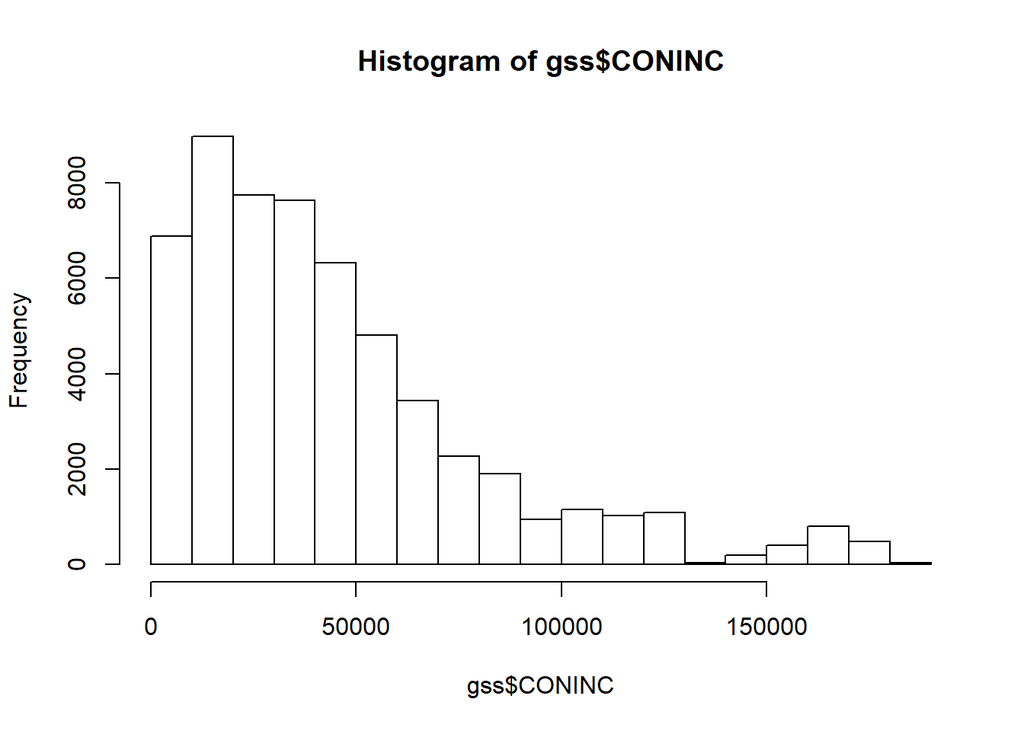

```r
?hist
?plot
?boxplot
hist(gss$CONINC)
```

See this [awesome ggplot2 tutorial](http://www.sthda.com/english/wiki/ggplot2-essentials) for clear, in-depth walkthroughs!

The package is called “ggplot2”, but the actual function to create a plot is `ggplot()` and requires three things:  
1) data  
2) “aes”thetics (this is where you define the coordinate system, define point colors and shapes, etc)  
3) “geom_”s (this is how you choose your data to be represented - points, lines, bars, ribbons, etc.)

We will walk through a histogram, boxplot, and scatterplot.

**Histogram** - look at the distribution of the CONINC variable

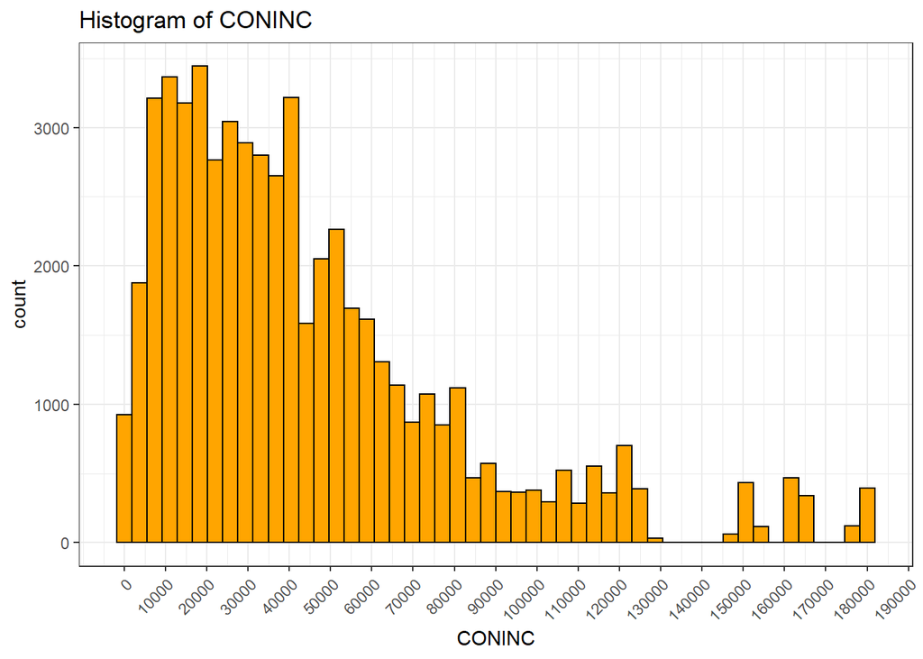

```r
library(ggplot2)
ggplot(data = gss, aes(x = CONINC)) +
  geom_histogram(fill = "orange", color = "black", bins = 50) +
  ggtitle("Histogram of CONINC") +
  scale_x_continuous(breaks = pretty(gss$CONINC, n = 20)) +
  theme_bw() +
  theme(axis.text.x = element_text(angle = 45, hjust = 1))
```

**Saving your figures** - in the “Plots” viewer (lower right pane), click Export, then either:  
* Save as image,  
* Save as PDF, or * Copy to Clipboard

Specify your options and then save it! Where do you think it is saved to? (hint: your working directory!)

**Boxplots** - again, let’s look at the distribution of the CONINC variable but this time as as parsed by the different levels of HEALTH.

Notice that we have included the `fill = HEALTH` argument inside `aes()`. This will color the boxes by the different levels of HEALTH (EXCELLENT, FAIR, GOOD, POOR). If this is too redundant, you can turn the legend off by deleting the two hashtags in the code below:

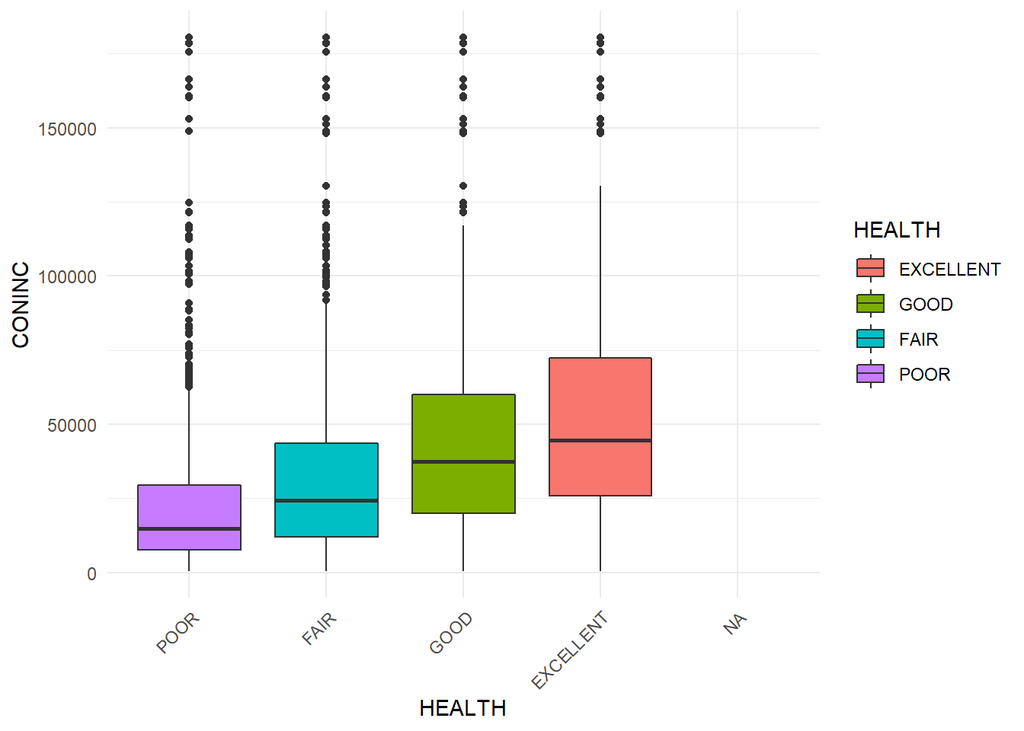

```r
ggplot(data = gss, aes(x = HEALTH, y = CONINC, fill = HEALTH)) +
  geom_boxplot() +
  theme_minimal() +
  scale_x_discrete(limits = c("POOR", "FAIR", "GOOD", "EXCELLENT", "NA")) +
  theme(axis.text.x = element_text(angle = 45, hjust = 1)) +
  ylab("CONINC") # +
```

```r
  # guides(fill = FALSE)
```

**Scatterplots** - are super fun in ggplot2. What do these different argument layers do? What might this scatterplot inform you about?

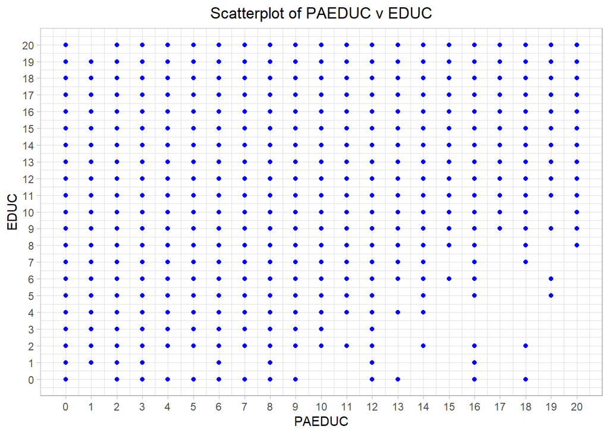

```r
# Scatterplot 1 - father's education
ggplot(data = gss, aes(x = PAEDUC, y = EDUC)) +
  geom_point(color = "blue") +
  theme_light() +
  ggtitle("Scatterplot of PAEDUC v EDUC") +
  xlab("PAEDUC") +
  ylab("EDUC") +
  theme(plot.title = element_text(hjust = 0.5)) +
  scale_x_continuous(breaks = pretty(gss$PAEDUC, n = 20)) +
  scale_y_continuous(breaks = seq(0, 20, by = 1))
```

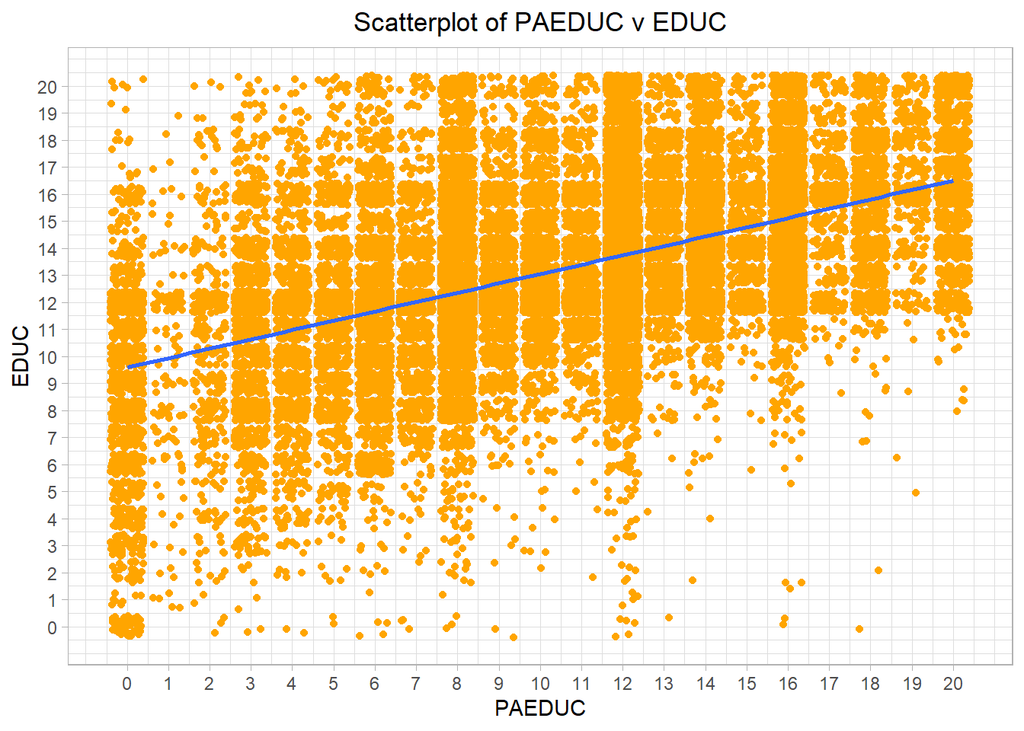

```r
# Points work well, but we want geom_jitter() instead!
ggplot(data = gss, aes(x = PAEDUC, y = EDUC)) +
  geom_jitter(color = "orange") +
  geom_smooth(method=lm)+
  theme_light() +
  ggtitle("Scatterplot of PAEDUC v EDUC") +
  xlab("PAEDUC") +
  ylab("EDUC") +
  theme(plot.title = element_text(hjust = 0.5)) +
  scale_x_continuous(breaks = pretty(gss$PAEDUC, n = 20)) +
  scale_y_continuous(breaks = seq(0, 20, by = 1))
```

**barplots** - you can also use barplots to create histogram-like plots using proportions (%) instead of actual numbers

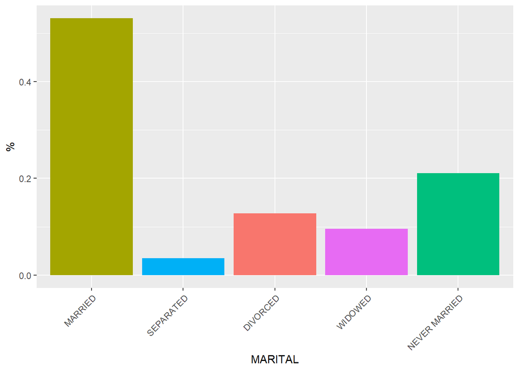

```r
# by percentage (%)
ggplot(gss, aes(x = MARITAL, fill = MARITAL)) +
  geom_bar(aes(y = (..count..)/sum(..count..))) +
  scale_x_discrete(limits = c("MARRIED", "SEPARATED", "DIVORCED", "WIDOWED", "NEVER MARRIED")) +
  theme(axis.text.x = element_text(angle = 45, hjust = 1)) +
  ylab("%") +
  guides(fill = FALSE)
```

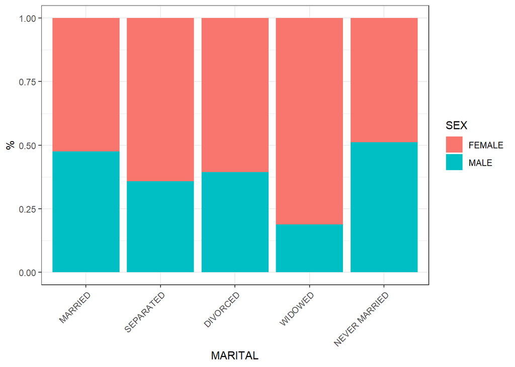

```r
# stacked percentage plot
ggplot(gss, aes(x = MARITAL)) +
  geom_bar(aes(fill = SEX), position = "fill") +
  theme_bw() +
  theme(axis.text.x = element_text(angle = 45, hjust = 1)) +
  ylab("%") +
  scale_x_discrete(limits = c("MARRIED", "SEPARATED", "DIVORCED", "WIDOWED", "NEVER MARRIED"))
```

## Appendix

The useful guideance of tidy census is https://walkerke.github.io/tidycensus/articles/basic-usage.html  
Before run this, you need to apply a cnesus API key. The website is https://www.census.gov/data/developers/guidance/api-user-guide.html

```r
#install.packages("tidycensus")
library(tidycensus)
Y18 <- load_variables(2018, "acs5", cache = TRUE)
head(Y18)
```

```
## # A tibble: 6 x 3
##   name      label                         concept
##   <chr>     <chr>                         <chr>
## 1 B00001_0~ Estimate!!Total               UNWEIGHTED SAMPLE COUNT OF THE P~
## 2 B00002_0~ Estimate!!Total               UNWEIGHTED SAMPLE HOUSING UNITS
## 3 B01001_0~ Estimate!!Total               SEX BY AGE
## 4 B01001_0~ Estimate!!Total!!Male         SEX BY AGE
## 5 B01001_0~ Estimate!!Total!!Male!!Under~ SEX BY AGE
## 6 B01001_0~ Estimate!!Total!!Male!!5 to ~ SEX BY AGE
```

```r
ca <- get_acs(geography = "county",
              variables = c(medincome = "B19013_001"),
              state = "CA",
              year = 2018)
ca
```

```
## # A tibble: 58 x 5
##    GEOID NAME                            variable  estimate   moe
##    <chr> <chr>                           <chr>        <dbl> <dbl>
##  1 06001 Alameda County, California      medincome    92574  1023
##  2 06003 Alpine County, California       medincome    64688 12933
##  3 06005 Amador County, California       medincome    61198  3241
##  4 06007 Butte County, California        medincome    48443  1477
##  5 06009 Calaveras County, California    medincome    58151  3310
##  6 06011 Colusa County, California       medincome    56704  4501
##  7 06013 Contra Costa County, California medincome    93712   926
##  8 06015 Del Norte County, California    medincome    45258  5035
##  9 06017 El Dorado County, California    medincome    80582  2117
## 10 06019 Fresno County, California       medincome    51261   808
## # ... with 48 more rows
```